# Mini-projet Séries Temporelles - socle classique en R

Production photovoltaïque journalière à Tunis (PVGIS, liens du rapport SolarVision) - option B

Ce document couvre en R les sections 1, 2, 3 et 6 de l’énoncé (préparation, exploration, ARIMA/SARIMA, VAR, cointégration, GARCH, prévision et évaluation). Les mêmes étapes sont codées en Python dans `mini_projet_python.ipynb`, qui contient aussi la modélisation avancée (section 4), le choix des variables et les extensions. Les deux langages lisent **les mêmes fichiers** (`data/datasets/`, produits par `python/collecte_donnees.py` à partir du lien PVGIS du rapport SolarVision), utilisent le même découpage et la même normale saisonnière : les résultats se comparent ligne à ligne.

**Packages requis** (versions utilisées) : R 4.6.0, forecast 9.0.2, urca 1.3-4, vars 1.6-1, tseries 0.10-63, FinTS 0.4-9, rugarch 1.5-6, lmtest 0.9-40, jsonlite 2.0.0.

```r
# Chargement des packages et graine : rugarch utilise un optimiseur à départs aléatoires, la graine
# garantit des résultats identiques d'une exécution à l'autre.
library(forecast); library(urca); library(vars); library(tseries)
library(FinTS); library(rugarch); library(lmtest); library(jsonlite)
set.seed(42)
for (d in c("figures", "resultats")) dir.create(d, showWarnings = FALSE)
```

# 1. Importation et préparation des données

| Variable | Source | Détail |
| --- | --- | --- |
| Production d’1 kWc (kWh/kWc) | PVGIS 5.3 (JRC), lien du rapport SolarVision | somme des puissances horaires simulées (SARAH3 + ERA5), pente optimale 33°, plein sud, pertes 14 % |
| Nébulosité, pluie, humidité | Open-Meteo (réanalyse ERA5) | moyennes ou cumuls journaliers |
| Température, amplitude thermique | PVGIS (ERA5) | agrégation des valeurs horaires |
| Aérosols (AOD 550 nm) | NASA POWER (MERRA-2) | journalier |

```r
# Lecture du jeu de données « photovoltaïque - Tunisie » (3 villes) et sélection de Tunis. Si le fichier
# manque, il faut d'abord lancer la collecte Python (téléchargement des API, environ 20 minutes).
f <- "data/datasets/tn_photovoltaique_journalier.csv"
if (!file.exists(f)) stop("Lancer d'abord : python python/collecte_donnees.py")
tn <- read.csv(f, stringsAsFactors = FALSE)
df <- tn[tn$site == "tunis", ]
df$date <- as.Date(df$date)
df <- df[order(df$date), ]
stopifnot(all(diff(df$date) == 1))                 # pas de jour manquant : la série est régulière
n <- nrow(df); n_train <- floor(0.9 * n); H <- 7
y_all <- df$pv_kwh_kwc
# Objet série temporelle natif, fréquence annuelle déclarée (365,25 jours par cycle).
y_ts <- ts(y_all, start = c(2005, 1), frequency = 365.25)
y_train <- y_all[1:n_train]
train <- df[1:n_train, ]
cat("Période :", format(df$date[1]), "->", format(df$date[n]), "|", n, "jours | apprentissage jusqu'au",
    format(df$date[n_train]), "(", n_train, "jours ) | test :", n - n_train, "jours\n")
```

```
## Période : 2005-01-01 -> 2023-12-31 | 6939 jours | apprentissage jusqu'au 2022-02-05 ( 6245 jours ) | test : 694 jours
```

```r
cat("Jours dont le rayonnement PVGIS a été imputé (trous de la base SARAH3) :", sum(df$jour_impute_pvgis), "\n")
```

```
## Jours dont le rayonnement PVGIS a été imputé (trous de la base SARAH3) : 13
```

**Lecture.** La série couvre 6939 jours, du 1er janvier 2005 au 31 décembre 2023, sans trou de date. Le découpage est chronologique : 6245 jours d’apprentissage (jusqu’au 05/02/2022) et 694 jours de test, soit près de deux années complètes. 13 jours ont une valeur imputée à la collecte : PVGIS y renvoyait un rayonnement nul alors que le soleil était levé (trous de la base satellitaire), voir la section 2.5 du notebook Python.

# 2. Analyse exploratoire

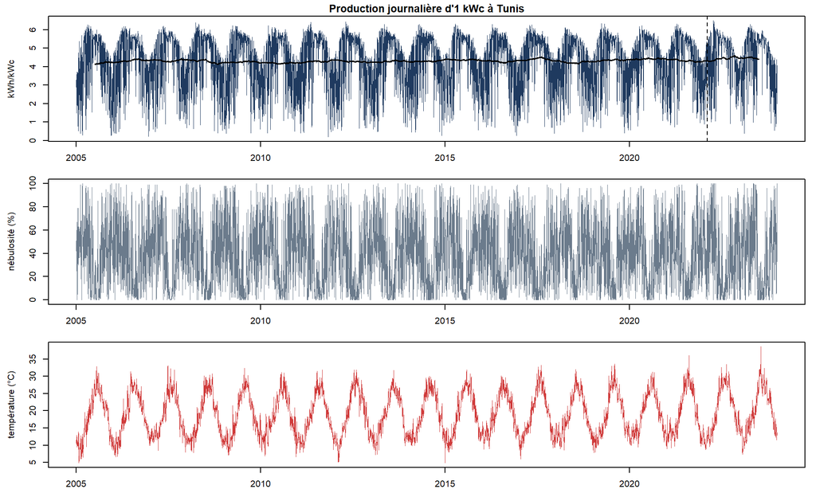

```r
# Production, nébulosité et température : trois échelles différentes, donc trois panneaux.
par(mfrow = c(3, 1), mar = c(2, 4.5, 1.5, 1))
plot(df$date, y_all, type = "l", lwd = 0.4, col = "#1f3a5f", xlab = "", ylab = "kWh/kWc",
     main = "Production journalière d'1 kWc à Tunis")
lines(df$date, stats::filter(y_all, rep(1 / 365, 365), sides = 2), col = "black", lwd = 1.5)
abline(v = df$date[n_train + 1], lty = 2)
plot(df$date, df$nebulosite_pct, type = "l", lwd = 0.4, col = "#6b7b8c", xlab = "", ylab = "nébulosité (%)")
plot(df$date, df$t2m_moy_c, type = "l", lwd = 0.4, col = "#d03b3b", xlab = "", ylab = "température (°C)")
```

```r
# Statistiques descriptives sur l'apprentissage (moments d'ordre 3 et 4 compris).
desc <- function(v) c(moyenne = mean(v), ecart_type = sd(v), min = min(v), max = max(v),
                      skewness = mean((v - mean(v))^3) / sd(v)^3, kurtosis_exces = mean((v - mean(v))^4) / sd(v)^4 - 3)
round(t(sapply(train[, c("pv_kwh_kwc", "nebulosite_pct", "t2m_moy_c", "precipitation_mm", "aerosols_aod")], desc)), 3)
```

```
##                  moyenne ecart_type   min     max skewness kurtosis_exces
## pv_kwh_kwc         4.295      1.402 0.211   6.427   -0.815         -0.279
## nebulosite_pct    38.295     27.333 0.000 100.000    0.355         -0.888
## t2m_moy_c         18.712      6.062 4.908  36.027    0.158         -1.104
## precipitation_mm   1.159      3.556 0.000  78.900    6.811         78.261
## aerosols_aod       0.245      0.195 0.030   2.830    3.346         20.007
```

```r
mois <- as.integer(format(train$date, "%m"))
round(rbind(moyenne = tapply(y_train, mois, mean), ecart_type = tapply(y_train, mois, sd)), 2)
```

```
##               1    2    3    4    5    6    7    8    9   10   11   12
## moyenne    3.20 3.67 4.23 4.73 4.99 5.21 5.43 5.22 4.45 3.98 3.40 3.06
## ecart_type 1.25 1.35 1.53 1.41 1.25 0.85 0.41 0.69 1.10 1.18 1.17 1.15
```

**Lecture.** La production moyenne vaut 4.29 kWh/kWc par jour, de 3.06 en décembre à 5.43 en juillet. La distribution est asymétrique à gauche (skewness -0.82) : la plupart des jours sont proches du maximum permis par la saison, quelques jours couverts sont très bas. L’écart-type mensuel varie en sens inverse du niveau (1.53 en mars contre 0.41 en juillet) : un logarithme amplifierait cette hétérogénéité au lieu de la corriger. La série est modélisée en niveau.

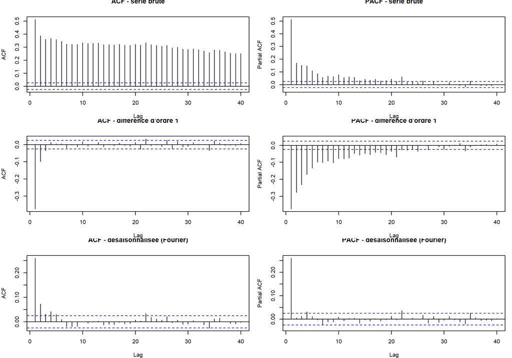

```r
# Termes de Fourier construits comme en Python (t = 0, 1, ... depuis le 1er janvier 2005) :
# ils représentent le cycle annuel déterministe.
fourier_k <- function(K, t = 0:(n - 1)) {
  M <- do.call(cbind, lapply(1:K, function(k) cbind(sin(2 * pi * k * t / 365.25), cos(2 * pi * k * t / 365.25))))
  colnames(M) <- paste0(rep(c("S", "C"), K), rep(1:K, each = 2)); M
}
F4 <- fourier_k(4)
anomalie <- y_all - cbind(1, F4) %*% coef(lm(y_train ~ F4[1:n_train, ]))
par(mfrow = c(3, 2), mar = c(4, 4, 2.5, 1))
Acf(y_train, lag.max = 40, main = "ACF - série brute"); Pacf(y_train, lag.max = 40, main = "PACF - série brute")
Acf(diff(y_train), lag.max = 40, main = "ACF - différence d'ordre 1"); Pacf(diff(y_train), lag.max = 40, main = "PACF - différence d'ordre 1")
Acf(anomalie[1:n_train], lag.max = 40, main = "ACF - désaisonnalisée (Fourier)"); Pacf(anomalie[1:n_train], lag.max = 40, main = "PACF - désaisonnalisée (Fourier)")
```

```r
a_acf <- acf(anomalie[1:n_train], plot = FALSE, lag.max = 7)$acf[-1]
a_pacf <- pacf(anomalie[1:n_train], plot = FALSE, lag.max = 7)$acf
round(rbind(ACF = a_acf, PACF = a_pacf), 3)
```

```
##      [,1]  [,2]  [,3]  [,4]  [,5]   [,6]   [,7]
## ACF  0.26 0.073 0.032 0.042 0.030  0.010 -0.019
## PACF 0.26 0.006 0.012 0.033 0.011 -0.003 -0.025
```

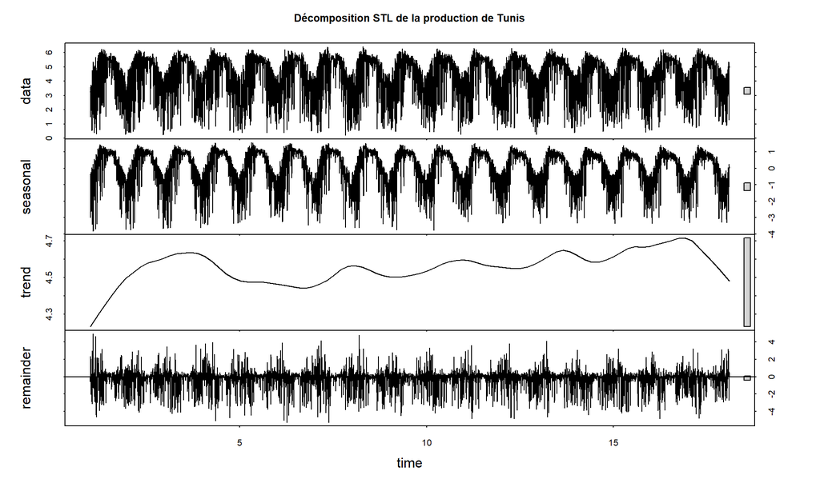

```r
# Décomposition STL robuste (période 365 jours) sur l'apprentissage.
dec <- stl(ts(y_train, frequency = 365), s.window = 7, robust = TRUE)
plot(dec, main = "Décomposition STL de la production de Tunis")
```

```r
comp <- dec$time.series
round(c(tendance = var(comp[, "trend"]), saison = var(comp[, "seasonal"]), residu = var(comp[, "remainder"])) / var(y_train), 3)
```

```
## tendance   saison   residu
##    0.003    0.580    0.629
```

**Lecture.** La composante saisonnière porte l’essentiel de la variance expliquée ; la tendance est presque plate (4.23 à 4.72 kWh/kWc), ce qui est attendu pour une installation de puissance constante ; le résidu, très variable l’hiver et presque nul l’été, contient la météo. Les parts de variance ne s’additionnent pas exactement à 1 car les composantes sont corrélées.

```r
# Boxplot glissant sur le résidu STL (quartiles sur 61 jours centrés) : la dispersion change avec la
# saison, une règle de l'IQR globale signalerait surtout les jours d'hiver.
r_stl <- as.numeric(comp[, "remainder"])
q_gl <- t(vapply(seq_along(r_stl), function(i) {
  w <- r_stl[max(1, i - 30):min(length(r_stl), i + 30)]; quantile(w, c(0.25, 0.75))
}, numeric(2)))
iqr <- q_gl[, 2] - q_gl[, 1]
ab <- r_stl < q_gl[, 1] - 1.5 * iqr | r_stl > q_gl[, 2] + 1.5 * iqr
bas <- ab & r_stl < 0
expl <- bas & (train$precipitation_mm >= 5 | train$nebulosite_pct >= 80 | train$aerosols_aod >= 0.8)
cat("Jours signalés :", sum(ab), "(", round(100 * mean(ab), 1), "% ) dont", sum(bas), "bas ;",
    sum(expl), "jours bas expliqués par la pluie, un ciel couvert ou des poussières\n")
```

```
## Jours signalés : 697 ( 11.2 % ) dont 549 bas ; 301 jours bas expliqués par la pluie, un ciel couvert ou des poussières
```

```r
# ADF (H0 : racine unitaire) et KPSS (H0 : stationnarité). Attention : tseries::adf.test inclut une
# tendance et fixe le nombre de retards, alors que statsmodels le choisit par AIC.
tests <- function(v, nom) {
  a <- adf.test(v); k <- kpss.test(v, null = "Level")
  data.frame(serie = nom, ADF_stat = round(a$statistic, 3), ADF_p = round(a$p.value, 4),
             KPSS_stat = round(k$statistic, 3), KPSS_p = round(k$p.value, 4))
}
tab_stat <- rbind(tests(y_train, "production"), tests(diff(y_train), "production - diff. ordre 1"),
                  tests(anomalie[1:n_train], "production - désaisonnalisée"),
                  tests(train$nebulosite_pct, "nébulosité"), tests(train$t2m_moy_c, "température"))
rownames(tab_stat) <- NULL
write.csv(tab_stat, "resultats/R_stationnarite.csv", row.names = FALSE)
tab_stat
```

| serie | ADF_stat | ADF_p | KPSS_stat | KPSS_p |
| --- | --- | --- | --- | --- |
| production | -7.515 | 0.01 | 0.077 | 0.1000 |
| production - diff. ordre 1 | -29.779 | 0.01 | 0.002 | 0.1000 |
| production - désaisonnalisée | -18.349 | 0.01 | 0.392 | 0.0805 |
| nébulosité | -9.407 | 0.01 | 0.098 | 0.1000 |
| température | -4.270 | 0.01 | 0.218 | 0.1000 |

**Lecture.** L’ADF rejette la racine unitaire pour toutes les séries (p < 0,01) et le KPSS ne rejette pas la stationnarité de la production (p > 0,05) : les deux tests concluent à une série stationnaire autour de son cycle annuel. **Ordre de différenciation retenu : d = 0**, le cycle annuel étant représenté par des termes de Fourier (saisonnalité déterministe), comme en Python.

# 3. Modélisation classique

## 3.1 ARIMA à termes de Fourier (régression harmonique dynamique)

```r
# Grille guidée par l'ACF/PACF : p et q faibles, d = 0, K harmoniques de 2 à 4 ; choix par BIC.
ordres <- list(c(1, 0, 0), c(2, 0, 0), c(3, 0, 0), c(1, 0, 1), c(2, 0, 1), c(1, 0, 2), c(2, 0, 2))
res_g <- do.call(rbind, lapply(2:4, function(K) do.call(rbind, lapply(ordres, function(o) {
  m <- tryCatch(Arima(y_train, order = o, xreg = fourier_k(K)[1:n_train, ], include.constant = TRUE),
                error = function(e) NULL)     # un candidat qui ne converge pas est ignoré
  if (is.null(m)) return(NULL)
  data.frame(ordre = paste(o, collapse = ","), K = K, AIC = AIC(m), BIC = BIC(m))
}))))
res_g <- res_g[order(res_g$BIC), ]; rownames(res_g) <- NULL
write.csv(res_g, "resultats/R_grille_arima.csv", row.names = FALSE)
head(res_g, 8)
```

| ordre | K | AIC | BIC |
| --- | --- | --- | --- |
| 1,0,0 | 2 | 18930.40 | 18977.58 |
| 1,0,0 | 3 | 18925.01 | 18985.67 |
| 1,0,1 | 2 | 18931.94 | 18985.85 |
| 2,0,0 | 2 | 18931.99 | 18985.91 |
| 1,0,2 | 2 | 18929.72 | 18990.37 |
| 2,0,1 | 2 | 18930.64 | 18991.30 |
| 3,0,0 | 2 | 18932.63 | 18993.29 |
| 1,0,1 | 3 | 18926.71 | 18994.10 |

```r
ORDRE <- as.integer(strsplit(res_g$ordre[1], ",")[[1]]); K_F <- res_g$K[1]
FK <- fourier_k(K_F)
```

```r
# Confirmation par recherche automatique : auto.arima choisit d et les ordres, mêmes termes de Fourier.
m_auto <- auto.arima(y_train, xreg = FK[1:n_train, ], seasonal = FALSE)
m_auto
```

```
## Series: y_train
## Regression with ARIMA(1,0,0) errors
##
## Coefficients:
##          ar1  intercept      S1       C1      S2       C2
##       0.2629     4.3006  0.1162  -1.1358  0.1131  -0.0820
## s.e.  0.0122     0.0189  0.0268   0.0267  0.0267   0.0267
##
## sigma^2 = 1.212:  log likelihood = -9458.2
## AIC=18930.4   AICc=18930.42   BIC=18977.58
```

```r
# Trois modèles : manuel, automatique, et manuel enrichi de la météo du jour (« ex post »).
meteo <- cbind(nebulosite = df$nebulosite_pct, neb_x_potentiel = df$nebulosite_pct / 100 * df$irr_extraterrestre_kwh_m2,
               precipitation = df$precipitation_mm, humidite = df$humidite_pct,
               amplitude = df$amplitude_thermique_c, aod = df$aerosols_aod)
X_meteo <- cbind(FK, meteo)
m_man <- Arima(y_train, order = ORDRE, xreg = FK[1:n_train, ], include.constant = TRUE)
m_meteo <- Arima(y_train, order = ORDRE, xreg = X_meteo[1:n_train, ], include.constant = TRUE)
modeles <- list("ARIMA-Fourier manuel" = m_man, "ARIMA-Fourier auto" = m_auto, "SARIMAX météo" = m_meteo)
data.frame(AIC = sapply(modeles, AIC), BIC = sapply(modeles, BIC), sigma = sqrt(sapply(modeles, function(m) m$sigma2)))
```

|  | AIC | BIC | sigma |
| --- | --- | --- | --- |
| ARIMA-Fourier manuel | 18930.40 | 18977.58 | 1.1008253 |
| ARIMA-Fourier auto | 18930.40 | 18977.58 | 1.1008253 |
| SARIMAX météo | 14428.44 | 14516.05 | 0.7673133 |

```r
coeftest(m_meteo)
```

```
##
## z test of coefficients:
##
##                   Estimate Std. Error  z value Pr(>|z|)
## ar1              0.1086476  0.0127483   8.5225  < 2e-16 ***
## intercept        4.5118232  0.1080335  41.7632  < 2e-16 ***
## S1               0.2519672  0.0172530  14.6043  < 2e-16 ***
## C1              -0.5560790  0.0283822 -19.5925  < 2e-16 ***
## S2              -0.0282019  0.0156448  -1.8026  0.07145 .
## C2              -0.3209750  0.0172882 -18.5661  < 2e-16 ***
## nebulosite      -0.0256372  0.0014029 -18.2750  < 2e-16 ***
## neb_x_potentiel  0.0471043  0.0167304   2.8155  0.00487 **
## precipitation   -0.0634710  0.0032515 -19.5205  < 2e-16 ***
## humidite         0.0022500  0.0013155   1.7104  0.08719 .
## amplitude        0.0930436  0.0043259  21.5084  < 2e-16 ***
## aod             -0.9645265  0.0619664 -15.5653  < 2e-16 ***
## ---
## Signif. codes:  0 '***' 0.001 '**' 0.01 '*' 0.05 '.' 0.1 ' ' 1
```

**Lecture.** La grille retient ARIMA(1,0,0) avec K = 2 harmoniques (BIC minimal). `auto.arima` retient Regression with ARIMA(1,0,0) errors. Avec la météo du jour, l’écart-type de l’erreur à un jour passe de 1.101 à 0.767 kWh/kWc. Les signes sont physiques : la nébulosité (-0.256 kWh/kWc pour 10 points), la pluie (-0.063 par mm) et les aérosols (-0.96 par unité d’épaisseur optique) réduisent la production ; l’amplitude thermique, signe d’un ciel clair, l’augmente.

```r
# Diagnostic des résidus : bruit blanc (Ljung-Box), normalité (Jarque-Bera), variance constante (ARCH-LM).
diagnostic <- function(m) {
  r <- as.numeric(residuals(m))[-(1:7)]
  k <- sum(grepl("^(ar|ma)", names(m$coef)))
  c(LB10_p = Box.test(r, lag = 10, type = "Ljung-Box", fitdf = k)$p.value,
    LB30_p = Box.test(r, lag = 30, type = "Ljung-Box", fitdf = k)$p.value,
    JB_p = jarque.bera.test(r)$p.value, skewness = mean((r - mean(r))^3) / sd(r)^3,
    kurtosis = mean((r - mean(r))^4) / sd(r)^4, ARCH_LM7_p = ArchTest(r, lags = 7)$p.value)
}
tab_diag <- t(sapply(modeles, diagnostic))
write.csv(tab_diag, "resultats/R_diagnostics_arima.csv")
round(tab_diag, 4)
```

```
##                      LB10_p LB30_p JB_p skewness kurtosis
## ARIMA-Fourier manuel 0.0921 0.2509    0  -0.9362   3.7124
## ARIMA-Fourier auto   0.0921 0.2509    0  -0.9362   3.7124
## SARIMAX météo        0.0621 0.0171    0  -0.5213   3.8318
##                      ARCH_LM7_p.Chi-squared
## ARIMA-Fourier manuel                      0
## ARIMA-Fourier auto                        0
## SARIMAX météo                             0
```

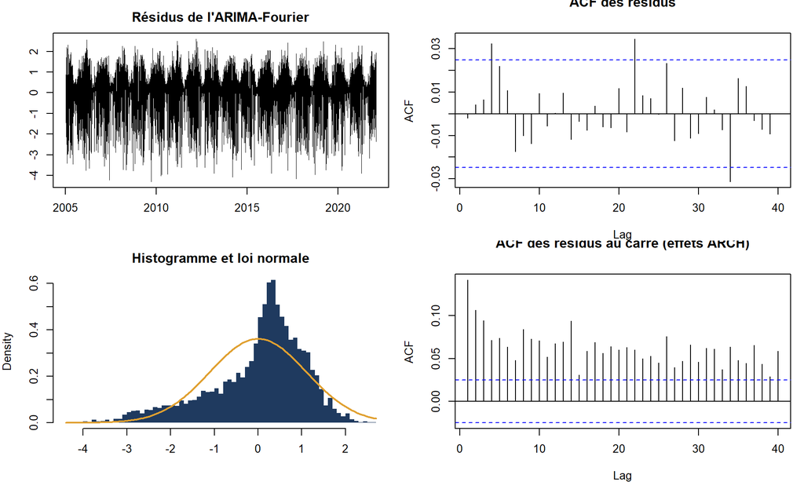

```r
# Les quatre vues qui accompagnent les tests : résidus dans le temps (variance saisonnière), ACF (indépendance),
# histogramme (normalité) et ACF des carrés (effets ARCH). Les 7 premiers résidus, phase de mise en route, sont écartés.
r_man <- as.numeric(residuals(m_man))[-(1:7)]
par(mfrow = c(2, 2), mar = c(4, 4, 2.5, 1))
plot(train$date[-(1:7)], r_man, type = "l", lwd = 0.4, xlab = "", ylab = "", main = "Résidus de l'ARIMA-Fourier")
Acf(r_man, lag.max = 40, main = "ACF des résidus")
hist(r_man, breaks = 80, freq = FALSE, col = "#1f3a5f", border = NA, main = "Histogramme et loi normale", xlab = "")
curve(dnorm(x, mean(r_man), sd(r_man)), add = TRUE, col = "#e0a030", lwd = 2)
Acf(r_man^2, lag.max = 40, main = "ACF des résidus au carré (effets ARCH)")
```

**Lecture du diagnostic.** Les résidus de l’ARIMA-Fourier manuel passent le test de Ljung-Box (p = 0.092 à 10 retards) : la structure d’autocorrélation est captée. La normalité est rejetée (asymétrie -0.94, kurtosis 3.71) : les mauvaises surprises (jours couverts) sont plus fortes que les bonnes, la production étant bornée par le ciel clair. L’homoscédasticité est massivement rejetée (ARCH-LM p < 0,001) : la variance des erreurs suit les saisons et les épisodes nuageux. C’est l’objet de la section 3.3.

## 3.1 bis SARIMA saisonnier sur la série mensuelle (s = 12)

```r
# Série mensuelle (somme des productions journalières) : période 12, SARIMA au sens strict.
mm <- tapply(y_all, format(df$date, "%Y-%m"), sum)
ym <- ts(as.numeric(mm), start = c(2005, 1), frequency = 12)
nm <- length(ym); nm_train <- floor(0.9 * nm)
ym_train <- window(ym, end = time(ym)[nm_train])
# Canova-Hansen demande le package uroot : on utilise le test de force saisonnière (« seas », défaut de forecast).
cat("D suggéré : OCSB =", nsdiffs(ym_train, test = "ocsb"), "| force saisonnière =", nsdiffs(ym_train, test = "seas"), "\n")
```

```
## D suggéré : OCSB = 0 | force saisonnière = 1
```

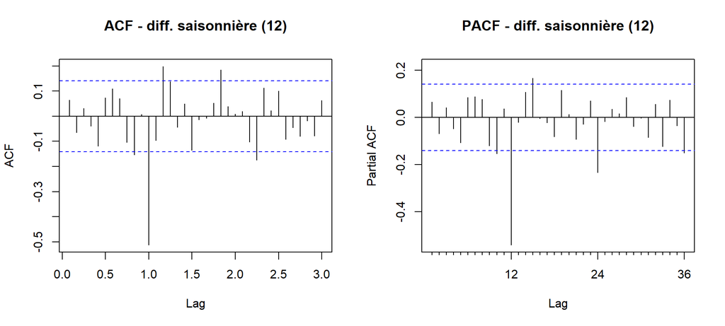

```r
par(mfrow = c(1, 2)); Acf(diff(ym_train, 12), lag.max = 36, main = "ACF - diff. saisonnière (12)")
Pacf(diff(ym_train, 12), lag.max = 36, main = "PACF - diff. saisonnière (12)")
```

```r
grille_m <- do.call(rbind, lapply(list(c(0, 0, 0), c(1, 0, 0), c(0, 0, 1), c(1, 0, 1)), function(o)
  do.call(rbind, lapply(list(c(0, 1, 1), c(1, 1, 0), c(1, 1, 1), c(2, 1, 0)), function(s) {
    m <- tryCatch(Arima(ym_train, order = o, seasonal = s), error = function(e) NULL)
    if (is.null(m)) return(NULL)
    data.frame(ordre = paste(o, collapse = ","), saisonnier = paste(s, collapse = ","), AIC = AIC(m), BIC = BIC(m))
  }))))
grille_m <- grille_m[order(grille_m$BIC), ]; rownames(grille_m) <- NULL
head(grille_m, 5)
```

| ordre | saisonnier | AIC | BIC |
| --- | --- | --- | --- |
| 0,0,0 | 0,1,1 | 1411.726 | 1418.251 |
| 0,0,0 | 1,1,1 | 1411.923 | 1421.711 |
| 0,0,1 | 0,1,1 | 1412.833 | 1422.621 |
| 1,0,0 | 0,1,1 | 1412.957 | 1422.745 |
| 0,0,1 | 1,1,1 | 1413.080 | 1426.131 |

```r
OM <- as.integer(strsplit(grille_m$ordre[1], ",")[[1]]); SM <- as.integer(strsplit(grille_m$saisonnier[1], ",")[[1]])
m_mens <- Arima(ym_train, order = OM, seasonal = SM)
m_mens_auto <- auto.arima(ym_train)
m_mens; m_mens_auto
```

```
## Series: ym_train
## ARIMA(0,0,0)(0,1,1)[12]
##
## Coefficients:
##          sma1
##       -0.8892
## s.e.   0.0728
##
## sigma^2 = 78.66:  log likelihood = -703.86
## AIC=1411.73   AICc=1411.79   BIC=1418.25
```

```
## Series: ym_train
## ARIMA(2,0,1)(0,1,2)[12] with drift
##
## Coefficients:
##           ar1      ar2     ma1     sma1    sma2   drift
##       -0.2763  -0.0816  0.3352  -0.9741  0.1257  0.0178
## s.e.   0.3931   0.0811  0.3899   0.0809  0.0839  0.0116
##
## sigma^2 = 78.6:  log likelihood = -700.46
## AIC=1414.92   AICc=1415.52   BIC=1437.76
```

```r
rm_ <- as.numeric(residuals(m_mens))[-(1:13)]
cat("Diagnostic : LB(12) p =", round(Box.test(rm_, 12, "Ljung-Box", fitdf = length(coef(m_mens)))$p.value, 4),
    "| JB p =", round(jarque.bera.test(rm_)$p.value, 4), "| ARCH-LM(4) p =", round(ArchTest(rm_, lags = 4)$p.value, 4), "\n")
```

```
## Diagnostic : LB(12) p = 0.2797 | JB p = 0.1554 | ARCH-LM(4) p = 0.9536
```

```r
# Évaluation à 6 mois depuis chaque origine du test.
HM <- 6; orig_m <- nm_train:(nm - HM)
Ym <- t(sapply(orig_m, function(t) ym[(t + 1):(t + HM)]))
clim_m <- tapply(as.numeric(ym_train), cycle(ym_train), mean)
pm_ <- list("Naïf saisonnier (même mois N-1)" = t(sapply(orig_m, function(t) ym[(t + 1 - 12):(t + HM - 12)])),
            "Moyenne mensuelle" = t(sapply(orig_m, function(t) clim_m[cycle(ym)[(t + 1):(t + HM)]])),
            "SARIMA manuel" = t(sapply(orig_m, function(t) forecast(Arima(ym[1:t], order = OM, seasonal = list(order = SM, period = 12),
                                                                       fixed = coef(m_mens), transform.pars = FALSE), h = HM)$mean)),
            "SARIMA auto" = t(sapply(orig_m, function(t) forecast(Arima(ts(ym[1:t], frequency = 12, start = c(2005, 1)), model = m_mens_auto), h = HM)$mean)))
tab_mens <- t(sapply(pm_, function(P) c(RMSE = sqrt(mean((Ym - P)^2)), MAE = mean(abs(Ym - P)), MAPE = 100 * mean(abs(Ym - P) / Ym))))
write.csv(tab_mens, "resultats/R_metriques_mensuel.csv")
round(tab_mens, 2)
```

```
##                                  RMSE   MAE MAPE
## Naïf saisonnier (même mois N-1) 17.70 13.47 9.87
## Moyenne mensuelle               12.26  9.69 7.15
## SARIMA manuel                   12.36  9.65 7.08
## SARIMA auto                     11.33  8.78 6.47
```

**Lecture.** Les deux tests divergent : OCSB ne demande pas de différence saisonnière, le test de force saisonnière en demande une. L’ACF de la différence saisonnière présente le pic négatif au retard 12 typique d’une moyenne mobile saisonnière, et le BIC retient SARIMA(0,0,0)(0,1,1)[12], dont le coefficient saisonnier vaut -0.89. Proche de -1, il annule presque la différence saisonnière : le modèle revient à une saisonnalité quasi déterministe, ce qui donne raison à OCSB. `auto.arima` retient un autre modèle que `pmdarima` en Python (voir ci-dessus). À 6 mois, le SARIMA manuel fait jeu égal avec la simple moyenne mensuelle (12.4 contre 12.3 kWh/kWc par mois) et bat nettement le naïf saisonnier (17.7) ; le modèle d’`auto.arima` fait un peu mieux (11.3), un écart qui reste à confirmer, l’évaluation ne portant que sur 18 origines. À cette échelle, il n’y a guère que le cycle annuel à prévoir.

## 3.2 VAR, causalité de Granger et cointégration

```r
# VAR en niveaux sur (production, nébulosité, température), cycle annuel en variables exogènes.
F3 <- fourier_k(3)
endog <- cbind(pv = df$pv_kwh_kwc, neb = df$nebulosite_pct, temp = df$t2m_moy_c)
sel <- VARselect(endog[1:n_train, ], lag.max = 14, type = "const", exogen = F3[1:n_train, ])
sel$selection
```

```
## AIC(n)  HQ(n)  SC(n) FPE(n)
##      3      3      3      3
```

```r
P_VAR <- as.integer(sel$selection["SC(n)"])
var_fit <- VAR(endog[1:n_train, ], p = P_VAR, type = "const", exogen = F3[1:n_train, ])
pt <- serial.test(var_fit, lags.pt = 20, type = "PT.asymptotic")
rv <- residuals(var_fit)
cat("VAR(", P_VAR, ") - Portmanteau(20) : p =", signif(pt$serial$p.value, 3), "| module max des racines :",
    round(max(roots(var_fit)), 3), "\n")
```

```
## VAR( 3 ) - Portmanteau(20) : p = 0.0183 | module max des racines : 0.729
```

```r
cat("Ljung-Box(10) par équation :", round(apply(rv, 2, function(v) Box.test(v, 10, "Ljung-Box")$p.value), 4), "\n")
```

```
## Ljung-Box(10) par équation : 0.5413 0.26 0.0801
```

```r
cat("ARCH-LM(7) par équation :", signif(apply(rv, 2, function(v) ArchTest(v, lags = 7)$p.value), 3), "\n")
```

```
## ARCH-LM(7) par équation : 8.32e-47 2.77e-17 4.89e-28
```

```r
# Causalité de Granger deux à deux : test de Wald (forme F) de la nullité des retards de la variable
# « cause » dans l'équation de la variable « effet », à partir de la matrice de covariance des coefficients.
granger <- do.call(rbind, lapply(colnames(endog), function(cause) do.call(rbind, lapply(setdiff(colnames(endog), cause), function(effet) {
  eq <- var_fit$varresult[[effet]]
  noms <- grep(paste0("^", cause, "\\.l"), names(coef(eq)), value = TRUE)
  b <- coef(eq)[noms]; V <- vcov(eq)[noms, noms]
  Fst <- as.numeric(t(b) %*% solve(V) %*% b) / length(noms)
  data.frame(cause = cause, effet = effet, F = Fst, p = pf(Fst, length(noms), df.residual(eq), lower.tail = FALSE))
}))))
write.csv(granger, "resultats/R_granger.csv", row.names = FALSE)
granger
```

| cause | effet | F | p |
| --- | --- | --- | --- |
| pv | neb | 14.294882 | 0.0000000 |
| pv | temp | 19.339562 | 0.0000000 |
| neb | pv | 98.750339 | 0.0000000 |
| neb | temp | 6.524384 | 0.0002110 |
| temp | pv | 2.898843 | 0.0336918 |
| temp | neb | 4.372900 | 0.0044130 |

**Lecture.** Le passé de la nébulosité aide fortement à prévoir la production (F = 98.8), et le passé de la production aide aussi à prévoir la nébulosité et la température : les trois séries décrivent le même état de l’atmosphère, et la causalité de Granger ne mesure que la prévisibilité. Le lien production vers température du lendemain a une explication physique (le rayonnement reçu réchauffe le sol et l’air). Ces statistiques se comparent à celles de `statsmodels`.

```r
# Cointégration sur le VAR de Tunis : séries stationnaires, le test de Johansen doit trouver le rang plein.
jo <- ca.jo(endog[1:n_train, ], type = "trace", ecdet = "const", K = max(P_VAR, 2), spec = "transitory")
tab_jo <- data.frame(H0 = rev(paste("r <=", 0:2)), trace = round(jo@teststat, 2), crit_5pct = jo@cval[, "5pct"])
tab_jo
```

|  | H0 | trace | crit_5pct |
| --- | --- | --- | --- |
| r <= 2 \| | r <= 2 | 62.29 | 9.24 |
| r <= 1 \| | r <= 1 | 992.74 | 19.96 |
| r = 0 \| | r <= 0 | 2129.39 | 34.91 |

```r
# Cas réellement non stationnaire : production solaire nationale mesurée, France (RTE) et Espagne (REE),
# mensuelle, en log, avec indicatrices saisonnières et tendance dans la relation de long terme.
rte <- read.csv("data/datasets/fr_solaire_national_rte_journalier.csv"); rte$date <- as.Date(rte$date)
ree <- read.csv("data/datasets/es_fotovoltaica_ree_journalier.csv"); ree$date <- as.Date(ree$date)
mensuel <- function(d, col) { m <- tapply(d[[col]], format(d$date, "%Y-%m"), function(v) if (length(v) >= 25) sum(v) else NA); m }
nat <- merge(data.frame(mois = names(mensuel(rte, "production_gwh")), fr = as.numeric(mensuel(rte, "production_gwh"))),
             data.frame(mois = names(mensuel(ree, "produccion_gwh")), es = as.numeric(mensuel(ree, "produccion_gwh"))))
nat <- na.omit(nat[nat$mois <= "2026-08", ])
lnat <- log(as.matrix(nat[, c("fr", "es")]))
cat("Période :", nat$mois[1], "->", nat$mois[nrow(nat)], "(", nrow(nat), "mois )\n")
```

```
## Période : 2014-01 -> 2026-08 ( 152 mois )
```

```r
# Comme en Python, les tests portent sur les séries désaisonnalisées (régression sur les mois) : sur la série
# brute, le cycle annuel fait passer pour un retour à la moyenne ce qui n'est qu'une saisonnalité.
mois_f <- factor(substr(nat$mois, 6, 7))
ldes <- apply(lnat, 2, function(v) residuals(lm(v ~ mois_f)) + mean(v))
adf_nat <- t(sapply(1:2, function(j) {
  t1 <- ur.df(ldes[, j], type = "trend", lags = 6, selectlags = "AIC")
  t2 <- ur.df(diff(ldes[, j]), type = "drift", lags = 6, selectlags = "AIC")
  c(tau_niveau = t1@teststat[1], seuil_5pct = t1@cval[1, 2], tau_difference = t2@teststat[1], seuil_5pct_diff = t2@cval[1, 2])
}))
rownames(adf_nat) <- c("log France (désaisonnalisé)", "log Espagne (désaisonnalisé)")
round(adf_nat, 2)
```

```
##                              tau_niveau seuil_5pct tau_difference
## log France (désaisonnalisé)       -2.74      -3.43         -12.54
## log Espagne (désaisonnalisé)      -2.34      -3.43         -12.72
##                              seuil_5pct_diff
## log France (désaisonnalisé)            -2.88
## log Espagne (désaisonnalisé)           -2.88
```

```r
jo_n <- ca.jo(lnat, type = "trace", ecdet = "trend", K = 4, season = 12, spec = "transitory")
tab_jo_n <- data.frame(H0 = rev(c("r = 0", "r <= 1")), trace = round(jo_n@teststat, 2), crit_5pct = jo_n@cval[, "5pct"])
write.csv(rbind(cbind(systeme = "Tunis", tab_jo), cbind(systeme = "France-Espagne", tab_jo_n)),
          "resultats/R_johansen.csv", row.names = FALSE)
tab_jo_n
```

|  | H0 | trace | crit_5pct |
| --- | --- | --- | --- |
| r <= 1 \| | r <= 1 | 5.59 | 12.25 |
| r = 0 \| | r = 0 | 15.34 | 25.32 |

```r
# Rang par la procédure séquentielle : premier r dont l'hypothèse « rang <= r » n'est pas rejetée.
stat_croiss <- rev(jo_n@teststat); crit_croiss <- rev(jo_n@cval[, "5pct"])
RANG_N <- which(stat_croiss <= crit_croiss)[1] - 1; if (is.na(RANG_N)) RANG_N <- 2
cat("Rang de cointégration France-Espagne :", RANG_N, "\n")
```

```
## Rang de cointégration France-Espagne : 0
```

```r
vecm <- cajorls(jo_n, r = 1)
cat("VECM de rang 1 (vérification) - beta :", round(vecm$beta[, 1], 4), "\n")
```

```
## VECM de rang 1 (vérification) - beta : 1 0.3391 -0.0193
```

```r
print(round(coef(summary(vecm$rlm))[[1]]["ect1", ], 4)); print(round(coef(summary(vecm$rlm))[[2]]["ect1", ], 4))
```

```
##   Estimate Std. Error    t value   Pr(>|t|)
##    -0.0603     0.0590    -1.0216     0.3089
```

```
##   Estimate Std. Error    t value   Pr(>|t|)
##    -0.2059     0.0696    -2.9562     0.0037
```

## 3.3 Volatilité conditionnelle : ARCH et GARCH

```r
# Variance conditionnelle des erreurs à un jour de l'ARIMA-Fourier manuel (kWh/kWc).
e <- r_man
cat("ARCH-LM(7) : p =", signif(ArchTest(e, lags = 7)$p.value, 3), "| ACF des carrés (1 à 7) :",
    round(acf(e^2, plot = FALSE, lag.max = 7)$acf[-1], 3), "\n")
```

```
## ARCH-LM(7) : p = 4.29e-47 | ACF des carrés (1 à 7) : 0.141 0.106 0.094 0.071 0.074 0.064 0.048
```

```r
spec <- function(modele, ordre, loi) ugarchspec(variance.model = list(model = modele, garchOrder = ordre),
                                                mean.model = list(armaOrder = c(0, 0), include.mean = FALSE),
                                                distribution.model = loi)
candidats <- list("GARCH(1,1) normale" = spec("sGARCH", c(1, 1), "norm"),
                  "GARCH(1,1) Student" = spec("sGARCH", c(1, 1), "std"),
                  "GARCH(1,1) Student asym." = spec("sGARCH", c(1, 1), "sstd"),
                  "GARCH(2,1) Student asym." = spec("sGARCH", c(2, 1), "sstd"),
                  "GJR-GARCH(1,1) Student asym." = spec("gjrGARCH", c(1, 1), "sstd"),
                  "EGARCH(1,1) Student asym." = spec("eGARCH", c(1, 1), "sstd"))
# Plusieurs solveurs, meilleure vraisemblance retenue : un optimum local fausserait la comparaison.
ajuster_garch <- function(sp) {
  essais <- lapply(c("hybrid", "solnp", "nlminb"), function(sv) tryCatch(ugarchfit(sp, e, solver = sv), error = function(err) NULL))
  essais <- Filter(function(g) !is.null(g) && convergence(g) == 0, essais)
  if (length(essais) == 0) return(NULL)
  essais[[which.max(sapply(essais, likelihood))]]
}
ajust <- Filter(Negate(is.null), lapply(candidats, ajuster_garch))
tab_g <- t(sapply(ajust, function(g) { zz <- as.numeric(residuals(g, standardize = TRUE))
  c(logLik = likelihood(g), AIC = infocriteria(g)[1] * length(e), BIC = infocriteria(g)[2] * length(e),
    LB10_z2_p = Box.test(zz^2, 10, "Ljung-Box")$p.value, ARCH_LM7_z_p = ArchTest(zz, lags = 7)$p.value) }))
write.csv(tab_g, "resultats/R_garch_comparaison.csv")
round(tab_g, 4)
```

```
##                                 logLik      AIC      BIC LB10_z2_p
## GARCH(1,1) normale           -9084.762 18175.52 18195.74    0.0696
## GARCH(1,1) Student           -8922.972 17853.94 17880.90    0.0182
## GARCH(1,1) Student asym.     -8213.439 16436.88 16470.57    0.0109
## GARCH(2,1) Student asym.     -8213.462 16438.92 16479.35    0.0110
## GJR-GARCH(1,1) Student asym. -8201.760 16415.52 16455.95    0.0138
## EGARCH(1,1) Student asym.    -8143.480 16298.96 16339.39    0.0414
##                              ARCH_LM7_z_p.Chi-squared
## GARCH(1,1) normale                             0.0313
## GARCH(1,1) Student                             0.0112
## GARCH(1,1) Student asym.                       0.0063
## GARCH(2,1) Student asym.                       0.0063
## GJR-GARCH(1,1) Student asym.                   0.0085
## EGARCH(1,1) Student asym.                      0.0265
```

```r
g11 <- ajust[["GARCH(1,1) Student asym."]]
round(coef(g11), 4)
```

```
##  omega alpha1  beta1   skew  shape
## 0.0093 0.1362 0.8628 0.5096 7.7770
```

```r
cat("Persistance alpha + beta :", round(sum(coef(g11)[c("alpha1", "beta1")]), 3), "\n")
```

```
## Persistance alpha + beta : 0.999
```

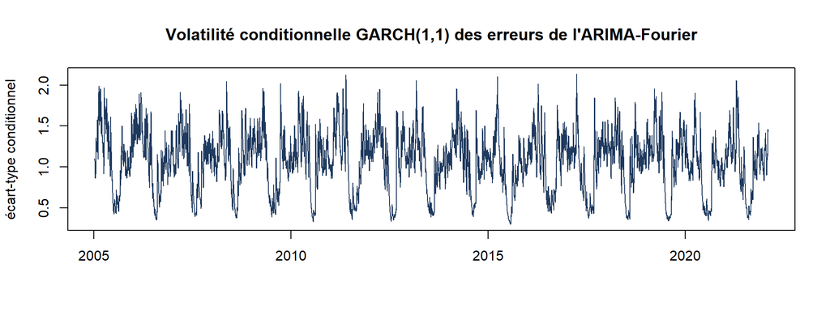

```r
# Volatilité conditionnelle dans le temps puis sa moyenne par mois : si elle suit le calendrier, le GARCH ne fait
# que reproduire une saisonnalité de la variance (hiver nuageux, été stable), pas des chocs persistants.
vol <- as.numeric(sigma(g11))
plot(train$date[-(1:7)], vol, type = "l", col = "#1f3a5f", xlab = "", ylab = "écart-type conditionnel",
     main = "Volatilité conditionnelle GARCH(1,1) des erreurs de l'ARIMA-Fourier")
```

```r
round(tapply(vol, format(train$date[-(1:7)], "%m"), mean), 3)
```

```
##    01    02    03    04    05    06    07    08    09    10    11    12
## 1.174 1.276 1.419 1.365 1.192 0.905 0.511 0.590 0.978 1.108 1.151 1.154
```

# 6. Prévision et évaluation

```r
# Normale saisonnière calculée exactement comme en Python : moyenne par jour de l'année sur
# l'apprentissage, lissée par une moyenne mobile circulaire de 31 jours.
jour <- pmin(as.integer(format(df$date, "%j")), 365)
lisser <- function(a) as.numeric(stats::filter(c(a, a, a), rep(1 / 31, 31), sides = 2))[366:730]
CLIM_M <- lisser(as.numeric(tapply(y_train, jour[1:n_train], mean)))[jour]
```

```r
# Origines glissantes sur tout le test ; paramètres figés à leur valeur estimée sur l'apprentissage.
# Le filtre est appliqué aux 500 derniers jours avant chaque origine : avec un AR(1) de coefficient
# voisin de 0,26, l'état filtré ne dépend pas des observations plus anciennes.
origines <- n_train:(n - H)
Y <- t(sapply(origines, function(t) y_all[(t + 1):(t + H)]))
prev_arima <- function(fit, X) {
  P <- B <- U <- matrix(NA, length(origines), H)
  for (i in seq_along(origines)) {
    t <- origines[i]; w <- (t - 499):t
    fc <- forecast(Arima(y_all[w], model = fit, xreg = X[w, , drop = FALSE]), h = H, level = 95,
                   xreg = X[(t + 1):(t + H), , drop = FALSE])
    P[i, ] <- fc$mean; B[i, ] <- fc$lower; U[i, ] <- fc$upper
  }
  list(moy = pmax(P, 0), bas = B, haut = U)
}
# VAR : prévision récursive depuis chaque origine avec les coefficients estimés sur l'apprentissage.
Bv <- Bcoef(var_fit)
prev_var <- t(sapply(origines, function(t) {
  hist <- endog[(t - P_VAR + 1):t, , drop = FALSE]; out <- numeric(H)
  for (h in 1:H) {
    z <- c(as.vector(t(hist[nrow(hist):(nrow(hist) - P_VAR + 1), , drop = FALSE])), 1, F3[t + h, ])
    yh <- as.numeric(Bv %*% z); out[h] <- yh[1]; hist <- rbind(hist, yh)
  }
  out
}))
prev <- list("Persistance (J)" = list(moy = t(sapply(origines, function(t) rep(y_all[t], H)))),
             "Climatologie" = list(moy = t(sapply(origines, function(t) CLIM_M[(t + 1):(t + H)]))),
             "ARIMA-Fourier manuel" = prev_arima(m_man, FK), "ARIMA-Fourier auto" = prev_arima(m_auto, FK),
             "VAR" = list(moy = prev_var), "SARIMAX météo (ex post)" = prev_arima(m_meteo, X_meteo))
```

```r
# Les quatre métriques de l'énoncé, calculées sur les mêmes origines et horizons pour tous les modèles (tableau
# unique), puis le RMSE par horizon : c'est lui qui montre où chaque modèle gagne ou perd.
metriques <- function(P) { e <- Y - P
  c(MSE = mean(e^2), RMSE = sqrt(mean(e^2)), MAE = mean(abs(e)), MAPE = 100 * mean(abs(e) / Y)) }
tab_m <- t(sapply(prev, function(p) metriques(p$moy)))
rmse_h <- t(sapply(prev, function(p) sqrt(colMeans((Y - p$moy)^2)))); colnames(rmse_h) <- paste0("RMSE_h", 1:H)
couv <- sapply(prev, function(p) if (is.null(p$bas)) NA else 100 * mean(Y >= p$bas & Y <= p$haut))
tab_m <- cbind(tab_m, couverture_IC95 = couv)
write.csv(cbind(tab_m, rmse_h), "resultats/R_metriques.csv")
round(tab_m, 4)
```

```
##                            MSE   RMSE    MAE    MAPE couverture_IC95
## Persistance (J)         2.0550 1.4335 0.9841 33.4743              NA
## Climatologie            1.2105 1.1002 0.8558 30.1908              NA
## ARIMA-Fourier manuel    1.1863 1.0892 0.8406 29.7317         94.9958
## ARIMA-Fourier auto      1.1863 1.0892 0.8406 29.7317         94.9958
## VAR                     1.1688 1.0811 0.8344 29.4671              NA
## SARIMAX météo (ex post) 0.5244 0.7242 0.5493 17.1087         95.2243
```

```r
round(rmse_h, 3)
```

```
##                         RMSE_h1 RMSE_h2 RMSE_h3 RMSE_h4 RMSE_h5 RMSE_h6 RMSE_h7
## Persistance (J)           1.236   1.390   1.471   1.489   1.489   1.476   1.466
## Climatologie              1.102   1.102   1.102   1.101   1.099   1.098   1.097
## ARIMA-Fourier manuel      1.030   1.090   1.101   1.102   1.101   1.100   1.099
## ARIMA-Fourier auto        1.030   1.090   1.101   1.102   1.101   1.100   1.099
## VAR                       1.009   1.076   1.093   1.097   1.097   1.097   1.096
## SARIMAX météo (ex post)   0.712   0.723   0.727   0.727   0.727   0.727   0.726
```

**Lecture.** Sans météo future, le meilleur modèle classique est VAR (RMSE 1.081 kWh/kWc), devant la persistance (1.434). L’ARIMA-Fourier ne bat la climatologie qu’aux tout premiers horizons : dès 2 ou 3 jours, sa prévision rejoint la normale saisonnière, conformément à la faible persistance (AR(1) de coefficient 0,26) vue en section 2. Avec la météo observée, le SARIMAX descend à 0.724 : c’est la valeur d’une bonne prévision météo, et une borne optimiste. La couverture des intervalles à 95 % est donnée dans la dernière colonne.

```r
# Diebold-Mariano (HLN) contre la climatologie et contre la persistance, horizons 1 et 7,
# pertes quadratique et absolue. Statistique positive = le modèle fait mieux que la référence.
dm <- do.call(rbind, lapply(c("Persistance (J)", "Climatologie"), function(ref)
  do.call(rbind, lapply(setdiff(names(prev), ref), function(nm) do.call(rbind, lapply(c(1, 7), function(h) {
    e_ref <- Y[, h] - prev[[ref]]$moy[, h]; e_mod <- Y[, h] - prev[[nm]]$moy[, h]
    d <- dm.test(e_ref, e_mod, h = h, power = 2); da <- dm.test(e_ref, e_mod, h = h, power = 1)
    data.frame(reference = ref, modele = nm, horizon = h, DM = as.numeric(d$statistic), p = d$p.value,
               DM_abs = as.numeric(da$statistic), p_abs = da$p.value)
  }))))))
write.csv(dm, "resultats/R_diebold_mariano.csv", row.names = FALSE)
dm[, 3:7] <- round(dm[, 3:7], 4)
dm
```

|  | reference | modele | horizon | DM | p | DM_abs | p_abs |
| --- | --- | --- | --- | --- | --- | --- | --- |
| DM | Persistance (J) | Climatologie | 1 | 2.8658 | 0.0043 | -1.1448 | 0.2527 |
| DM1 | Persistance (J) | Climatologie | 7 | 6.1578 | 0.0000 | 3.7774 | 0.0002 |
| DM2 | Persistance (J) | ARIMA-Fourier manuel | 1 | 5.3997 | 0.0000 | 1.1622 | 0.2456 |
| DM11 | Persistance (J) | ARIMA-Fourier manuel | 7 | 6.1227 | 0.0000 | 3.8288 | 0.0001 |
| DM3 | Persistance (J) | ARIMA-Fourier auto | 1 | 5.3997 | 0.0000 | 1.1622 | 0.2456 |
| DM12 | Persistance (J) | ARIMA-Fourier auto | 7 | 6.1227 | 0.0000 | 3.8288 | 0.0001 |
| DM4 | Persistance (J) | VAR | 1 | 5.7808 | 0.0000 | 2.0270 | 0.0430 |
| DM13 | Persistance (J) | VAR | 7 | 6.2013 | 0.0000 | 3.8378 | 0.0001 |
| DM5 | Persistance (J) | SARIMAX météo (ex post) | 1 | 9.7512 | 0.0000 | 8.5064 | 0.0000 |
| DM14 | Persistance (J) | SARIMAX météo (ex post) | 7 | 7.9816 | 0.0000 | 8.3126 | 0.0000 |
| DM6 | Climatologie | Persistance (J) | 1 | -2.8658 | 0.0043 | 1.1448 | 0.2527 |
| DM15 | Climatologie | Persistance (J) | 7 | -6.1578 | 0.0000 | -3.7774 | 0.0002 |
| DM21 | Climatologie | ARIMA-Fourier manuel | 1 | 5.3157 | 0.0000 | 6.9213 | 0.0000 |
| DM111 | Climatologie | ARIMA-Fourier manuel | 7 | -0.3079 | 0.7583 | 0.5986 | 0.5496 |
| DM31 | Climatologie | ARIMA-Fourier auto | 1 | 5.3157 | 0.0000 | 6.9213 | 0.0000 |
| DM121 | Climatologie | ARIMA-Fourier auto | 7 | -0.3079 | 0.7583 | 0.5986 | 0.5496 |
| DM41 | Climatologie | VAR | 1 | 5.2320 | 0.0000 | 6.7206 | 0.0000 |
| DM131 | Climatologie | VAR | 7 | 0.3493 | 0.7270 | 0.9383 | 0.3484 |
| DM51 | Climatologie | SARIMAX météo (ex post) | 1 | 10.1652 | 0.0000 | 12.8928 | 0.0000 |
| DM141 | Climatologie | SARIMAX météo (ex post) | 7 | 6.6902 | 0.0000 | 8.0319 | 0.0000 |